# Bootstrap

Yan Shuo Tan

```r
knitr::opts_chunk$set(echo = TRUE)
library(tidyverse)
library(boot)
source("bootstrap_util.R")
```

We will demonstrate the bootstrap by applying it to a dataset comprising student grades. This dataset is described in Wasserman exercise 2 (page 39), and also apparently in the original bootstrap paper. LSAT is an examination for entrance to law school.

```r
scores <- tibble(lsat = c(576, 635, 558, 578, 666, 580, 555, 661, 651, 605, 653, 575, 545, 572, 594),
                 gpa = c(3.39, 3.30, 2.81, 3.03, 3.44, 3.07, 3.00, 3.43, 3.36, 3.13, 3.12, 2.74, 2.76, 2.88, 3.96))
```

## Sample mean

Warm-up: Recall that the bootstrap is meant to estimate the distribution of a statistic $T$. For the warm-up, we choose $T$ to be the sample mean for gpa. Note the general code in `bootstrap_util.R`

```r
sm_boot <- bootstrap0(x = scores$gpa,
                      B = 1000,
                      func = mean)
head(sm_boot, n = 10)
```

```
##  [1] 3.082667 3.116000 3.148667 3.298000 3.197333 3.245333 3.049333
##  [8] 3.105333 3.125333 3.458667
```

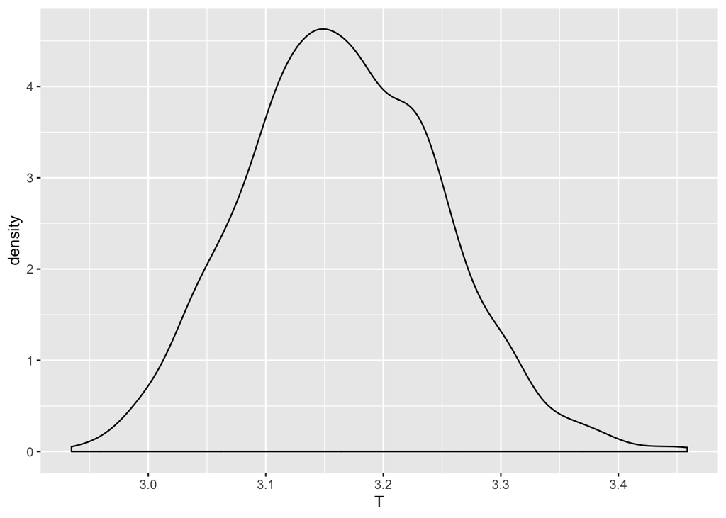

```r
ggplot(data = tibble(T = sm_boot)) + geom_density(aes(x = T))
```

The variance of the sample mean can be estimated using that of the empirical distribution `sm_boot`.

```r
var(sm_boot)
```

```
## [1] 0.006885162
```

We now compute confidence intervals using the different methods.

```r
CIs <- matrix(0, nrow = 4, ncol = 2)
ci_funcs <-  c(normal_interval, percentile_interval, pivotal_interval, studentized_pivotal_interval)
for (i in 1:4) {
  CIs[i, ] <- ci_funcs[[i]](x = scores$gpa,
                            B = 1000,
                            func = mean,
                            alpha = 0.05)
}
CI_df <- tibble(lower = CIs[, 1], upper = CIs[, 2])
CI_df[["type"]] <- c("Normal interval", "Percentile interval",
                     "Pivotal interval", "Studentized pivotal interval")
CI_df %>% select(type, everything())
```

```
## # A tibble: 4 × 3
##   type                         lower upper
##   <chr>                        <dbl> <dbl>
## 1 Normal interval               3.00  3.32
## 2 Percentile interval           3.01  3.34
## 3 Pivotal interval              3.00  3.30
## 4 Studentized pivotal interval  3.02  3.37
```

Note that the studentized pivotal interval requires a double bootstrap.

```r
double_bootstrap0(x = scores$gpa, B = 100, mean)
```

```
## # A tibble: 100 × 2
##    T_boot T_boot_var
##     <dbl>      <dbl>
##  1   3.22    0.00573
##  2   3.10    0.00836
##  3   3.30    0.00581
##  4   3.05    0.00458
##  5   3.01    0.00265
##  6   3.07    0.00352
##  7   3.15    0.0109
##  8   3.24    0.0131
##  9   3.23    0.00854
## 10   3.23    0.00561
## # … with 90 more rows
```

## Correlation between LSAT and GPA

We now try to estimate the correlation coefficient
$$\text{Corr}(Y,Z) =
\frac{\text{Cov}(Y,Z)}{\text{Var}(Y)^{1/2}\text{Var}(Z)^{1/2}}$$
where $Y$ and $Z$ refer to LSAT and GPA scores respectively.

```r
print(corr(scores))
```

```
## [1] 0.5459189
```

```r
corr_boot <- bootstrap0(x = scores,
                        B = 1000,
                        func = corr)
head(corr_boot, n = 10)
```

```
##  [1] 0.5886295 0.9424541 0.6790115 0.4079581 0.9377339 0.5048704 0.8322137
##  [8] 0.4983796 0.5630035 0.6137311
```

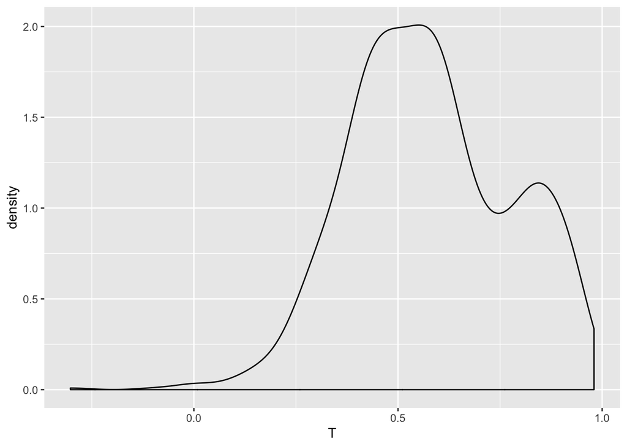

```r
ggplot(data = tibble(T = corr_boot)) + geom_density(aes(x = T))
```

The variance of the sample correlation can be estimated using that of the empirical distribution `corr_boot`.

```r
var(corr_boot)
```

```
## [1] 0.03886835
```

We now compute confidence intervals using the different methods.

```r
CIs <- matrix(0, nrow = 4, ncol = 2)
ci_funcs <-  c(normal_interval, percentile_interval, pivotal_interval, studentized_pivotal_interval)
for (i in 1:4) {
  CIs[i, ] <- ci_funcs[[i]](x = scores,
                            B = 1000,
                            func = corr,
                            alpha = 0.05)
}
CI_df <- tibble(lower = CIs[, 1], upper = CIs[, 2])
CI_df[["type"]] <- c("Normal interval", "Percentile interval",
                     "Pivotal interval", "Studentized pivotal interval")
CI_df %>% select(type, everything())
```

```
## # A tibble: 4 × 3
##   type                          lower upper
##   <chr>                         <dbl> <dbl>
## 1 Normal interval               0.156 0.936
## 2 Percentile interval           0.193 0.951
## 3 Pivotal interval              0.163 0.859
## 4 Studentized pivotal interval -1.14  0.830
```

## Where bootstrap fails: The sample maximum

```r
set.seed(42)
theta <- 1
X <- runif(50, min = 0, max = theta)
print(max(X))
```

```
## [1] 0.9888917
```

```r
max_boot <- bootstrap0(x = X,
                       B = 1000,
                       func = max)
```

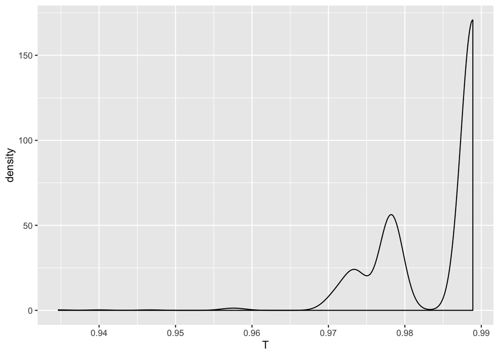

```r
ggplot(data = tibble(T = max_boot)) + geom_density(aes(x = T))
```

True distribution of $\hat{\theta}$ satisfies
$$\begin{align*}
F_{\hat{\theta}}(x) & = \mathbb{P}\lbrace \max_i X_i \leq x \rbrace
\\
& = \mathbb{P}\lbrace X_i \leq x \rbrace^n \\
& = F(x)^n \\
& = x^n
\end{align*}$$
Clearly the bootstrap distribution does not match the true density. Let us try the parametric bootstrap. The max likelihood estimate for $\theta$ is
$$\hat{\theta}_{MLE} = \max_{1 \leq i \leq n} X_i$$
This is because
$$f(\theta) = (1/\theta)^n 1(\theta \geq \max X_i).$$

The parametric bootstrap therefore simulates from the uniform distribution on $[0, \hat{\theta}_{MLE}]$.

```r
set.seed(42)
theta <- 1
X <- runif(50, min = 0, max = theta)
print(max(X))
```

```
## [1] 0.9888917
```

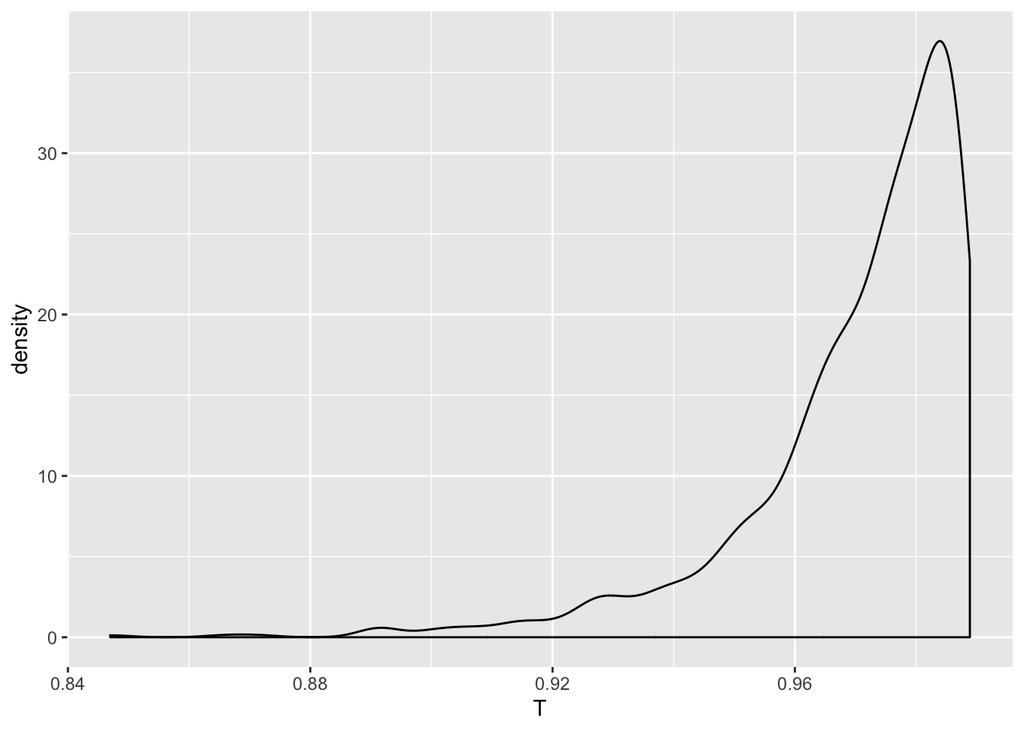

```r
max_boot_param <- vector("numeric", 1000)
for (b in 1:1000) {
  max_boot_param[[b]] <- max(runif(50, min = 0, max = max(X)))
}
ggplot(data = tibble(T = max_boot_param)) + geom_density(aes(x = T))
```

This is much closer to the true density. Why is nonparametric bootstrap bad? (Homework)